# Assignment03

# 学生：左小幸(12132243)

# 得分：48/50

# 1. Niño 3.4 index

The Niño 3.4 anomalies may be thought of as representing the average equatorial SSTs across the Pacific from about the dateline to the South American coast (5N-5S, 170W-120W). The Niño 3.4 index typically uses a 3-month running mean, and El Niño or La Niña events are defined when the Niño 3.4 SSTs exceed +/- 0.5°C for a period of 5 months or more. Check Equatorial Pacific Sea Surface Temperatures for more about the Niño 3.4 index.

In this problem set, you will use the sea surface temperature (SST) data from NOAA. Download the netCDF4 file (NOAA_NCDC_ERSST_v3b_SST.nc) here.

### 1.1 [5 points] Compute monthly climatology for SST from Niño 3.4 region, and subtract climatology from SST time series to obtain anomalies.

```python
# import models
import numpy as np
import pandas as pd
import xarray as xr
from matplotlib import pyplot as plt
```

```python
nne = xr.open_dataset('NOAA_NCDC_ERSST_v3b_SST.nc')

#select nino3.4 area and convert sst dataset to dataframe
sst = nne.sst.sel(lon=slice(190,240),lat=slice(-5,5)).mean(dim='lat').mean(dim='lon').to_dataframe().reset_index()

#calculate month average sst in history
month_average_sst = nne.sst.sel(lon=slice(190,240),lat=slice(-5,5)).mean(dim='lat').mean(dim='lon').groupby(nne.time.dt.month).mean().to_dataframe().reset_index()
```

```python
#combine two dataframes
sst['month_average_sst'] = 0
for i in range(1,13):
    sst['month_average_sst'].loc[sst['time'].dt.month == i] = month_average_sst.iloc[i-1]['sst']
```

[output not shown]

```python
#calculate anomalies
sst['anomalies'] = sst['sst'] - sst['month_average_sst']
```

```python
#result
sst
```

|  | time | sst | month_average_sst | anomalies |
| --- | --- | --- | --- | --- |
| 0 | 1960-01-15 | 26.248539 | 26.568117 | -0.319578 |
| 1 | 1960-02-15 | 26.274080 | 26.742603 | -0.468523 |
| 2 | 1960-03-15 | 26.971758 | 27.239906 | -0.268148 |
| 3 | 1960-04-15 | 27.507061 | 27.694029 | -0.186968 |
| 4 | 1960-05-15 | 27.617924 | 27.795525 | -0.177601 |
| ... | ... | ... | ... | ... |
| 679 | 2016-08-15 | 26.176836 | 26.824581 | -0.647745 |
| 680 | 2016-09-15 | 26.098179 | 26.738199 | -0.640020 |
| 681 | 2016-10-15 | 25.820841 | 26.717512 | -0.896671 |
| 682 | 2016-11-15 | 25.722893 | 26.693666 | -0.970774 |
| 683 | 2016-12-15 | 25.758188 | 26.613451 | -0.855263 |

684 rows × 4 columns

```python
#calculate the 3-month running mean as 'nino3.4' column
sst['nino3.4'] = 0
for i in range(2,684):
    sst['nino3.4'].iloc[i] = sst['anomalies'].iloc[i-2:i+1].mean()
```

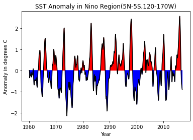

```python
#ploting
plt.plot(sst['time'],sst['nino3.4'],'k-')
plt.xlabel('Year')
plt.ylabel('Anomaly in degrees C')
plt.fill_between(sst['time'],0,sst['nino3.4'],sst['nino3.4']>0, color='r')
plt.fill_between(sst['time'],0,sst['nino3.4'],sst['nino3.4']<0, color='b')
plt.title('SST Anomaly in Nino Region(5N-5S,120-170W)')
plt.show()
```

# 2.Earth’s energy budget

In this problem set, you will analyze top-of-atmosphere (TOA) radiation data from NASA’s CERES project. Read this post for more about Earth’s energy budget. Download the data (CERES_EBAF-TOA_200003-201701.nc) here. The size of the data file is 702.5 MB. It will take a minute or two to download. Start by importing xarray, numpy, and matplotlib.

### 2.1 [5 points] Make a 2D plot of the time-mean TOA longwave, shortwave, and solar radiation for all-sky conditions. Add up the three variables above and verify (visually) that they are equivalent to the TOA net flux.

```python
cet = xr.open_dataset('CERES_EBAF-TOA_200003-201701.nc')

#shortwave
shortwave = cet.toa_sw_all_mon.mean(dim='time')

#longwave
longwave = cet.toa_lw_all_mon.mean(dim='time')

#solar radiation
solar_radiation = cet.solar_mon.mean(dim='time')

#add up
lss = (cet.solar_mon - cet.toa_lw_all_mon - cet.toa_sw_all_mon).mean(dim='time')
```

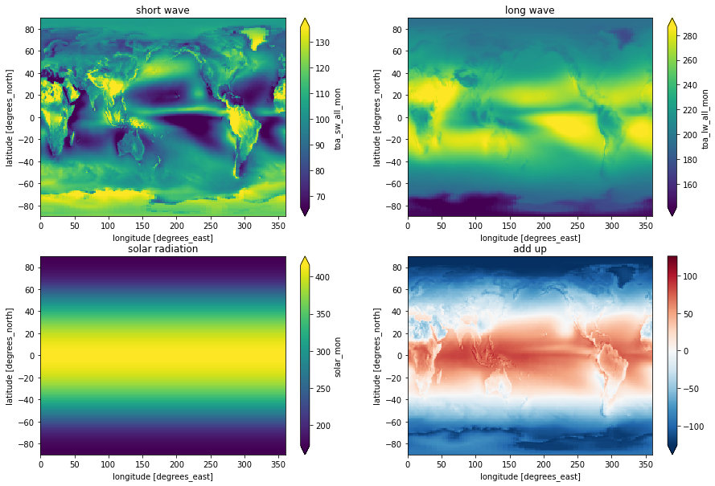

```python
# Plot 4 panels
f, ((ax1, ax2), (ax3, ax4)) = plt.subplots(nrows=2,ncols=2, figsize=(15, 10))

shortwave.plot(ax = ax1, robust=True)
ax1.set_title('short wave')

longwave.plot(ax=ax2, robust=True)
ax2.set_title('long wave')

solar_radiation.plot(ax=ax3, robust=True)
ax3.set_title('solar radiation')

lss.plot(ax=ax4, robust=True)
ax4.set_title('add up')
```

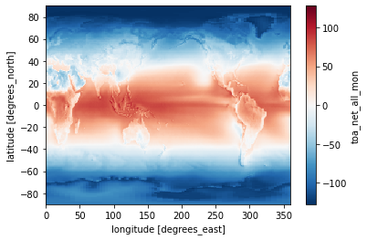

```python
cet.toa_net_all_mon.mean(dim='time').plot()
```

[Hint: Consider calculating the area of each grid]

```python
# Create the weights
weights = np.cos(np.deg2rad(cet.lat))

# incoming solar radiation
weights_solar_mon = cet.solar_mon.weighted(weights)
weights_solar_mon.mean()
```

```
<xarray.DataArray 'solar_mon' ()>
array(340.28326598)
```

```python
# outgoing longwave
weights_toa_lw_all_mon = cet.toa_lw_all_mon.weighted(weights)
weights_toa_lw_all_mon.mean()
```

```
<xarray.DataArray 'toa_lw_all_mon' ()>
array(240.26693375)
```

```python
# outgoing shortwave
weights_toa_sw_all_mon = cet.toa_sw_all_mon.weighted(weights)
weights_toa_sw_all_mon.mean()
```

```
<xarray.DataArray 'toa_sw_all_mon' ()>
array(99.13805277)
```

### 2.3 [5 points] Calculate and plot the total amount of net radiation in each 1-degree latitude band. Label with correct units.

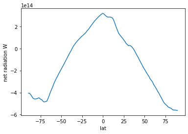

```python
# The area of 1-degree latitude band at the equator
earth_radius = 6371*1e3
equator_area = (3.14159*2*earth_radius)**2/360

# Create the weights
weights = np.cos(np.deg2rad(cet.lat))

# The area of 1-degree latitude band at the equator
equator_area = (3.14159*2*earth_radius)**2/360

# total amount of net radiation in each 1-degree latitude band
#lat_rad = equator_area*cet.toa_net_all_mon.mean(dim=('time','lon')).weighted(weights)

a = cet.toa_net_all_mon.weighted(weights).mean(dim=('time','lon'))*equator_area
a.plot()
plt.ylabel('net radiation W')
```